# lacomp

Travis

August 5, 2018

# Looking at LA County employee salaries

In this post, we will be examining which LA County emplooyes are getting paid the most and which departments and positions are taking home the most compensation. After looking through these charts, I have a feeling that some of you will be asking yourself, “Why don’t I work for LA County?”

In an effort to be transparent, LA has published this dataset that contains the salary information on 123,000 unique LA County employees over 5 years from 2013-2017. In total there are 524,113 rows and 20 variables. These variables include the name, department, position title, pension contributions, leave time payouts, total benefits, base pay, and total compensation (among several others) for each employee.

```r
library(tidyverse)
library(data.table)
library(ggrepel)
df <- fread('la_emp.csv', stringsAsFactors = F)
```

```
##
Read 43.9% of 524113 rows
Read 89.7% of 524113 rows
Read 524113 rows and 20 (of 20) columns from 0.088 GB file in 00:00:04
```

```r
colnames(df) <- make.names(colnames(df))
```

Let’s start by looking at median salaries for some of the most common positions in LA County.

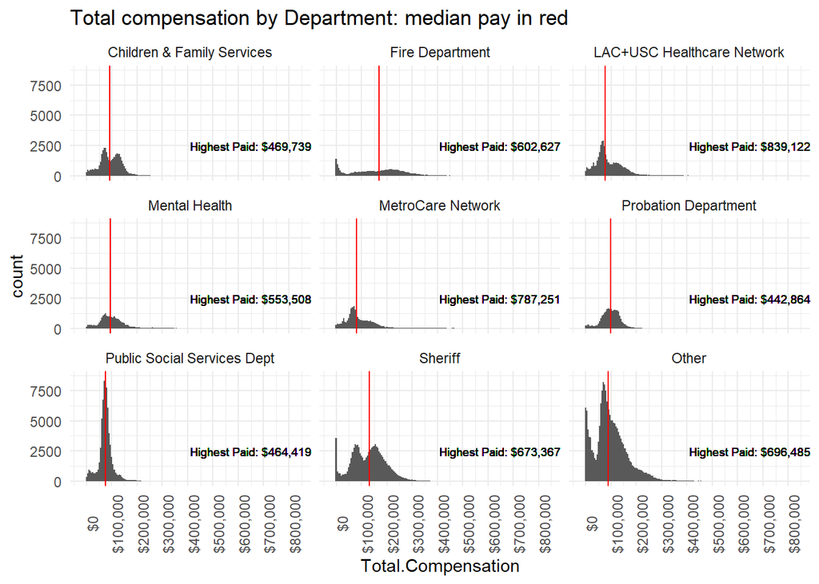

```r
#in order to plot median, add median column using same group_by
df <- df%>%
  group_by(dep = fct_lump(Department, n=8))%>%
  mutate(med = median(Total.Compensation),
         max_comp = max(Total.Compensation))%>%
  ungroup()

df%>%
  group_by(dep = fct_lump(Department, n=8))%>%
  ggplot(aes(Total.Compensation))+
  geom_histogram(binwidth = 5000)+
  scale_x_continuous(breaks = scales::pretty_breaks(n=7),labels = scales::dollar)+
  facet_wrap(~ dep, ncol=3,nrow=3)+
  geom_vline(aes(xintercept = med, group = dep), colour = 'red')+
  geom_text(aes(x=650000, y=2500, label = paste('Highest Paid:', scales::dollar(max_comp)), group=dep), size=2.5)+
  theme_minimal()+
  theme(axis.text.x = element_text(angle=90))+
  labs(title='Total compensation by Department: median pay in red')
```

# Leave Time Payouts

As has been noted in a few news articles, upon retirement some LA County employees can receive unused leave/vacation pay benefits of $100,000 or more. This has led some to suggest putting a cap on the number of unused sick, comp, holiday, and vacation days (e.g., 80 sick day maximum). Let’s see roughly how many people are collecting huge leave time payouts.

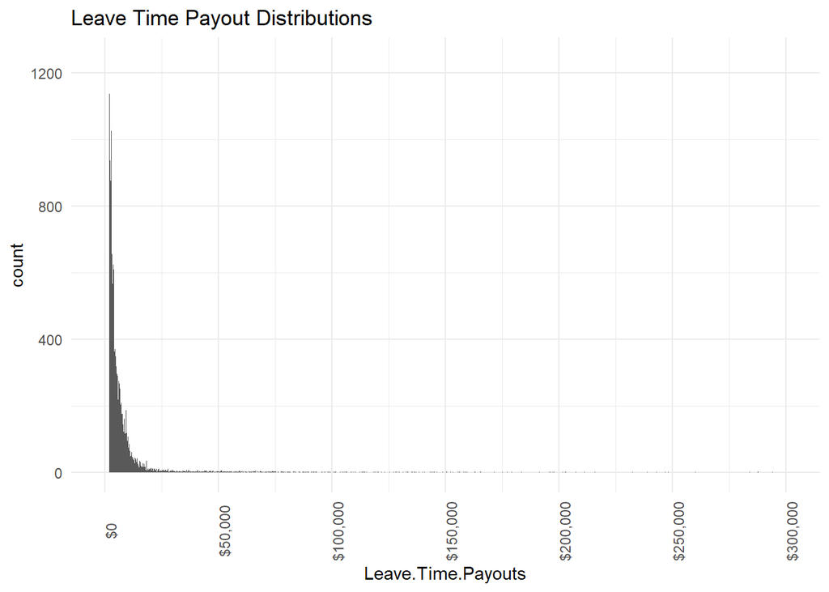

```r
df%>%
  filter(Leave.Time.Payouts > 2000)%>%
  ggplot(aes(Leave.Time.Payouts))+
  geom_histogram(bins=8000)+
  scale_x_continuous(breaks = scales::pretty_breaks(n=7),labels = scales::dollar)+
  coord_cartesian(xlim=c(0,300000))+
  theme_minimal()+
  theme(axis.text.x = element_text(angle=90))+
  labs(title='Leave Time Payout Distributions')
```

Yes, indeed there is a very small but noticeable segment of employees that are collecting between $50-300k upon retirement. Part of this is due to union contracts that allow employees to accrue all these unused days and get them paid out in a lump sum, according to this article: http://articles.latimes.com/2012/jan/07/local/la-me-county-pay-20120108

It’s not shown in the chart above, but most of these big payouts come from the Sheriff’s department or from firefighters.

# Comparing Overtime Pay for the Most Common Job Titles

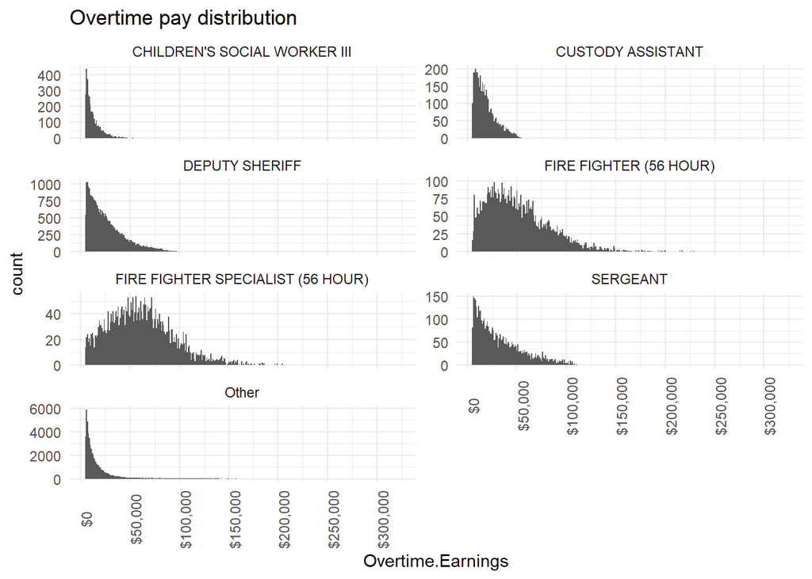

```r
#compare dist. of overtime earnings by top 10 positions. firefighters brining in cash overtime
df%>%
  filter(Overtime.Earnings > 5000)%>%
  group_by(position = fct_lump(Position.Title, n=6))%>%
  ggplot(aes(Overtime.Earnings))+
  geom_histogram(binwidth = 1000)+
  scale_x_continuous(breaks = scales::pretty_breaks(n=7),labels = scales::dollar)+
  facet_wrap(~ position, ncol=2, scales='free_y')+
  theme_minimal()+
  theme(axis.text.x = element_text(angle=90))+
  labs(title='Overtime pay distribution')
```

We can see that most of these common jobs don’t have much overtime pay, but for sheriffs, sergeants, and firefighters there is substantial overtime pay. In fact, for the average fire fighter, it looks like she takes home about at least $25,000 in overtime per year.

# Which Employees are Banking the Most Overtime Earnings?

From the charts above, we can see some people are making hundreds of thousands in extra income from their overtime pay. Which people are these?

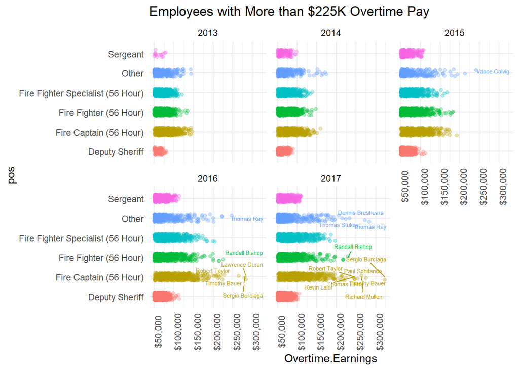

```r
library(ggrepel)
set.seed(1)

#completed
#KEY IS geom_point( position=position_jitter(width.2 height=.2)) and ifelse!
df%>%
  filter(Overtime.Earnings > 50000, Employee.Name != '')%>%
  group_by(pos = str_to_title(fct_lump(Position.Title, n=5)))%>%
  ggplot(aes(pos, Overtime.Earnings, color=pos))+
  geom_point(alpha=.3, position = position_jitter(width=.2, height=.1))+
  geom_text_repel(aes(label=ifelse(Overtime.Earnings > 225000,str_to_title(as.character(Employee.Name)),'')),size=2)+
  scale_y_continuous(breaks = scales::pretty_breaks(n=7),labels = scales::dollar)+
  guides(color=FALSE)+
  coord_flip()+
  theme_minimal()+
  theme(axis.text.x = element_text(angle=90))+
  facet_wrap(~ Year)+
  labs(title='Employees with More than $225K Overtime Pay')
```

Again you can see just how many people are earning overtime pay over $50,000 per year. And there are some people, such as Thomas Ray, who have made at least half a million dollars in overtime in just two years. Prior to 2016, only one person made more than $225,000 in overtime, but that number has increased quite a bit since then. This is likely due to the spate of wildfires in California over the past years.

To learn more about the specific people, you can check out this article: #http://www.culvercityobserver.com/story/2018/06/14/opinion/los-angeles-firefighter-earns-half-a-million-via-overtime/7595.html

# Closer Look at Overtime Pay for Departments

As we’ve seen, some departments have vast amounts of overtime pay, while others have next to none. Let’s take a closer look by first filtering out anyone who makes less than $10,000 in overtime, and then counting the most common job titles among those not removed.

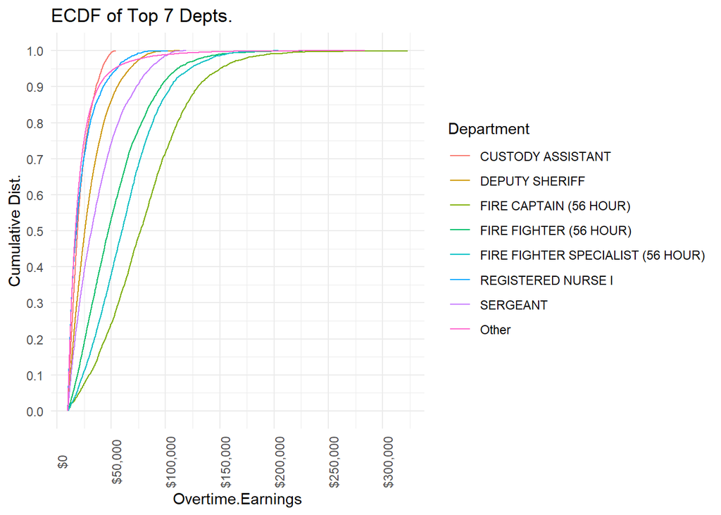

```r
 df%>%
   filter(Overtime.Earnings > 10000)%>%
   group_by(top_dep = fct_lump(Position.Title, n=7))%>%
   ungroup()%>%
   ggplot(aes(Overtime.Earnings, color=top_dep))+
   stat_ecdf(pad=FALSE)+
   scale_x_continuous(breaks = scales::pretty_breaks(n=7),labels = scales::dollar)+
   scale_y_continuous(breaks = seq(0,1, by=.10))+
   theme_minimal()+
   theme(axis.text.x = element_text(angle=90))+
   labs(color='Department', y='Cumulative Dist.', title='ECDF of Top 7 Depts.')
```

This ECDF chart highlights the huge disparity in overtime earnings from the different departments. For example, 99% of Custody Assistants make less than $50k in overtime, but only 25% of Fire Captains make less than $50k in overtime!

Fire Captains in the 95th percentile are making about $150k in overtime, compared to registered nurses in the same percentile bracket who would be making $50,000.

# Base Pay For Different Job Titles

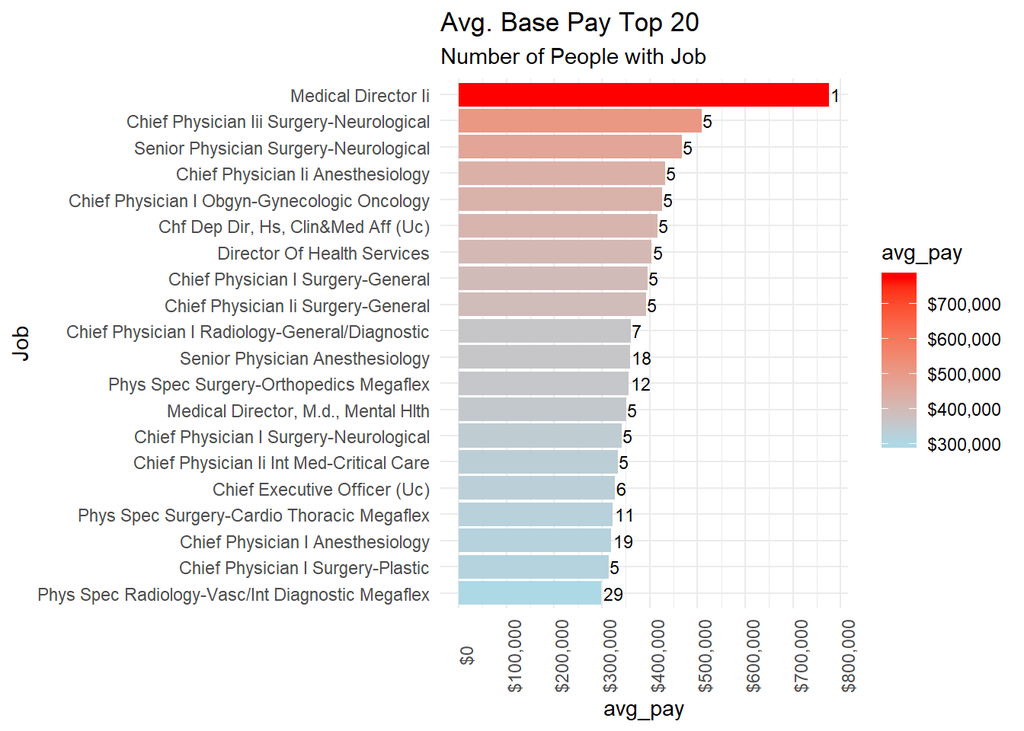

```r
#top base pay. COmplete
 df%>%
   group_by(Position.Title)%>%
   summarize(n = n(),
             avg_pay = mean(Base.Earnings))%>%
   arrange(desc(avg_pay))%>%
   head(20)%>%
   ggplot(aes(x=reorder(str_to_title(Position.Title), avg_pay), y=avg_pay, fill=avg_pay)) +
   geom_col() +
   coord_flip()+
   #labs(x="", y="% Level4") +
   geom_text(aes(x = reorder(str_to_title(Position.Title), avg_pay), label = n), size=3, hjust=-0.1) +
   scale_y_continuous(breaks = scales::pretty_breaks(n=7),labels = scales::dollar)+
   scale_fill_continuous(labels= scales::dollar, low='light blue', high='red')+
   theme_minimal()+
   theme(axis.text.x = element_text(angle=90))+
   labs(x='Job', title='Avg. Base Pay Top 20', subtitle='Number of People with Job')
```

We can see that pretty much every top-paying job is related to medicine. Neurosurgeons’ base pay is just slightly higher than anesthesiologists’ and onocologists’.

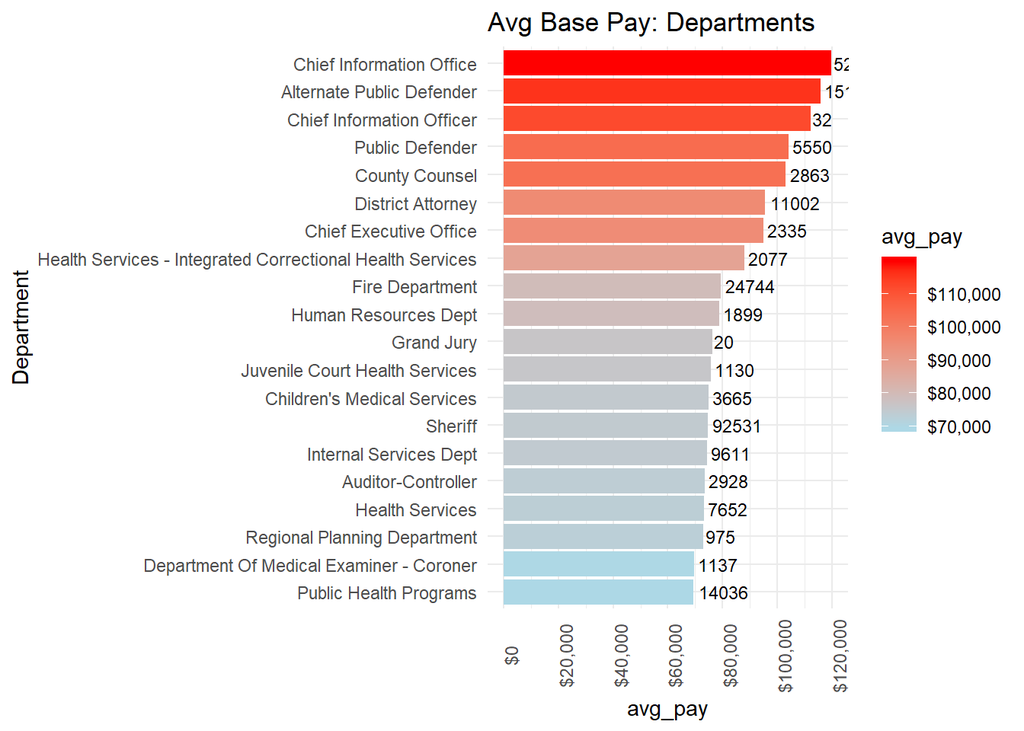

```r
 #complete departments
 df%>%
   group_by(Department)%>%
   summarize(n = n(),
             avg_pay = mean(Base.Earnings))%>%
   arrange(desc(avg_pay))%>%
   head(20)%>%
   ggplot(aes(x=reorder(str_to_title(Department), avg_pay), y=avg_pay, fill=avg_pay)) +
   geom_col() +
   coord_flip()+
   #labs(x="", y="% Level4") +
   geom_text(aes(x = reorder(str_to_title(Department), avg_pay), label = n), size=3, hjust=-0.1) +
   scale_y_continuous(breaks = scales::pretty_breaks(n=7),labels = scales::dollar)+
   scale_fill_continuous(labels= scales::dollar, low='light blue', high='red')+
   theme_minimal()+
   theme(axis.text.x = element_text(angle=90))+
   labs(title='Avg Base Pay: Departments', x='Department')
```

Looks like the legal and information departments pull down the biggest salaries. But there are relatively few people working in those departments. For example, there are only 52 employees in the Chief Information Office, but nearly 93,000 LA County Sheriffs.

# Total Budgets: What is the total compensation paid by each department?

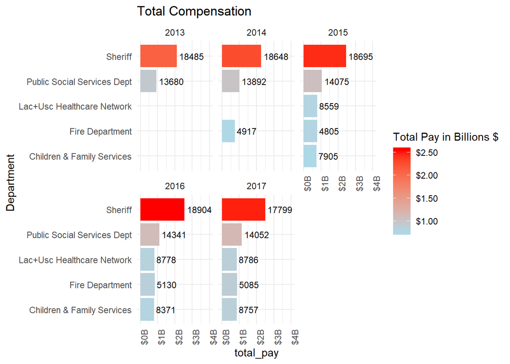

```r
#budget expenditures by department
 #complete departments
 df%>%
   group_by(Year,Department)%>%
   summarize(n = n(),
             total_pay = sum(Total.Compensation)/1000000000)%>%
   arrange(desc(total_pay))%>%
   head(20)%>%
   ggplot(aes(x=reorder(str_to_title(Department), total_pay), y=total_pay, fill=total_pay)) +
   geom_col() +
   coord_flip()+
   #labs(x="", y="% Level4") +
   geom_text(aes(x = reorder(str_to_title(Department), total_pay), label = n), size=3, hjust=-0.1) +
   scale_y_continuous(breaks = seq(0,12,1),labels = paste0('$',seq(0,12,1),'B'), limits= c(0,4))+
   scale_fill_continuous(labels= scales::dollar, low='light blue', high='red')+
   facet_wrap(~Year)+
   theme_minimal()+
   theme(axis.text.x = element_text(angle=90))+
   labs(fill='Total Pay in Billions $', x='Department', title='Total Compensation')
```

We can see that Sheriffs makes up a big share of the total compensation, simply because there are so many employees. Each year the Sheriff’s department is spending about $2 billion dollars in employee compensation. Also note that the total Sheriffs budget for 2015 was about $4 Billion. This means about half of that budget goes towards employee compensation.

Also we can see that the number of Sheriffs has gone down since 2013. There is currently a shortage of Sheriffs in LA County, and one effect of this shortage is that current Sheriffs will need to work more overtime. This is one reason why Sheriffs showed up on our chart of the jobs with the biggest amount of overtime pay.

# Which Departments Receive Greatest Share of Compensation?

We’ll re-do the above chart and focus on the percentage of all LA County employee compensation by department. We already know the Sheriffs pay the most in compensation, but what % of all compensation is Sheriffs compensation?

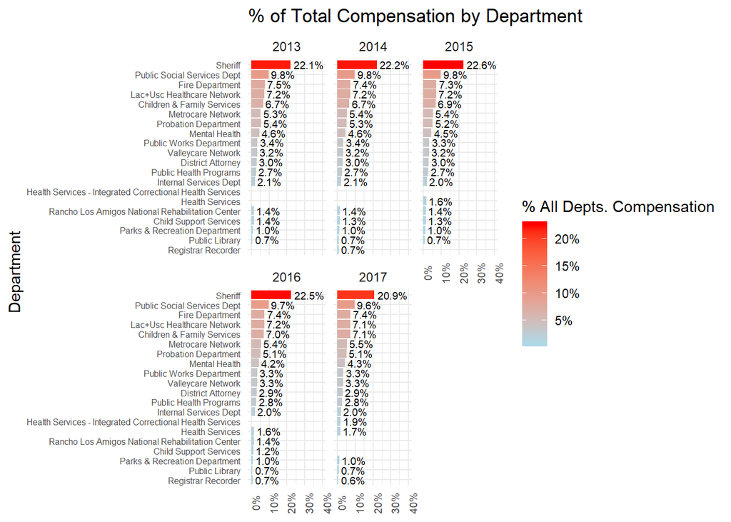

```r
df%>%
   group_by(Year,Department)%>%
   summarize(n = n(),
             total_pay = sum(Total.Compensation))%>%
   mutate(perc_budge = total_pay/sum(total_pay))%>%
   arrange(desc(perc_budge))%>%
   filter(n > 1500)%>%
   ggplot(aes(x=reorder(str_to_title(Department), perc_budge), y=perc_budge, fill=perc_budge)) +
   geom_col() +
   coord_flip()+
   #labs(x="", y="% Level4") +
   geom_text(aes(x = reorder(str_to_title(Department), perc_budge), label = scales::percent(perc_budge)), size=2.5, hjust=-0.1) +
   scale_y_continuous(labels = scales::percent, limits = c(0,.40))+
   scale_fill_continuous(labels = scales::percent, low='light blue', high='red')+
   theme_minimal()+
   facet_wrap(~ Year)+
   labs(fill='% All Depts. Compensation', title='% of Total Compensation by Department', y='', x='Department')+
  theme(axis.text.x = element_text(angle=90)) + theme(axis.text.x = element_text(size = 7),
    axis.text.y = element_text(size = 6)) +labs(y = NULL)
```

We can think of this chart as showing how much of LA’s ‘compensation pie’ is going to each department. Of course we need police, but should LA really be spending over 20% of its compensation budget on Sheriffs? I’m not an expert, but that seems quite high to me.

# Basepay to Overtime Pay Ratio

In this chart, we will look at the jobs where employees tend to earn relatively low base pay but high amounts of overtime pay. We do this by creating a ratio of the average extra compensation (total compensation - base earnings) and dividing by the average base salary.

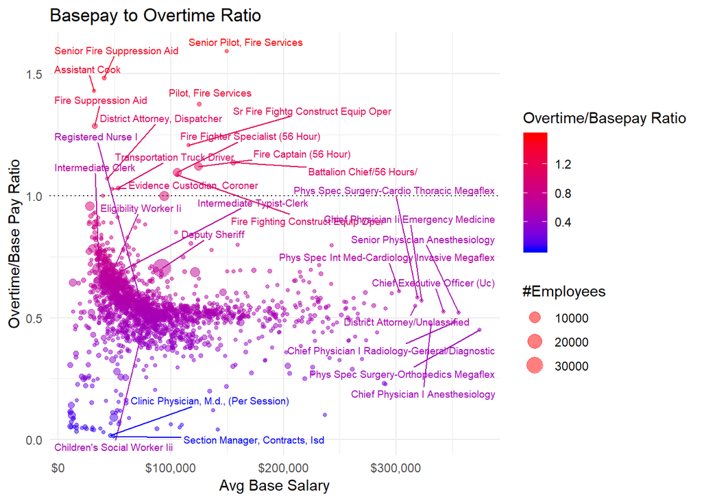

```r
library(RColorBrewer)
  df%>%
    group_by(Position.Title)%>%
    mutate(extra_sal = Total.Compensation - Base.Earnings)%>%
    arrange(desc(extra_sal))%>%
    group_by(Position.Title)%>%
    summarize(n = n(),
              avg_base = median(Base.Earnings),
              avg_extra = median(extra_sal))%>%
    filter(avg_base > 10000 & n > 5)%>%
    mutate(extra_rat = avg_extra/avg_base)%>%
    arrange(desc(extra_rat))%>%
    ungroup()%>%
    ggplot(aes(avg_base, extra_rat, color=extra_rat, size=n))+
    geom_point(alpha=.5)+
    scale_x_continuous(labels = scales::dollar)+
    scale_color_gradient(low='blue', high='red')+
    geom_text_repel(aes(label = ifelse(extra_rat > 1.0 | avg_base > 300000 | extra_rat < .025 | n > 10000, str_to_title(as.character(Position.Title)), '')), size=2.5, force=8)+
    labs(x='Avg Base Salary', y='Overtime/Base Pay Ratio', title='Basepay to Overtime Ratio',
         size='#Employees', color="Overtime/Basepay Ratio")+
    theme_minimal()+
    geom_hline(yintercept = 1.0, linetype = 'dotted')+
    guides(size=guide_legend(override.aes=list(colour="red")))
```

In contrast, an Assistant Cook earns about $45k base, but earns on average another $45k or more in extra compensation. So Assistant cooks have a high overtime/base ratio. At the very top of this ratio are Senior Pilots in Fire Services, who earn quite a bit base salary ($150k) and then average over 1.5X that amount in extra compensation.

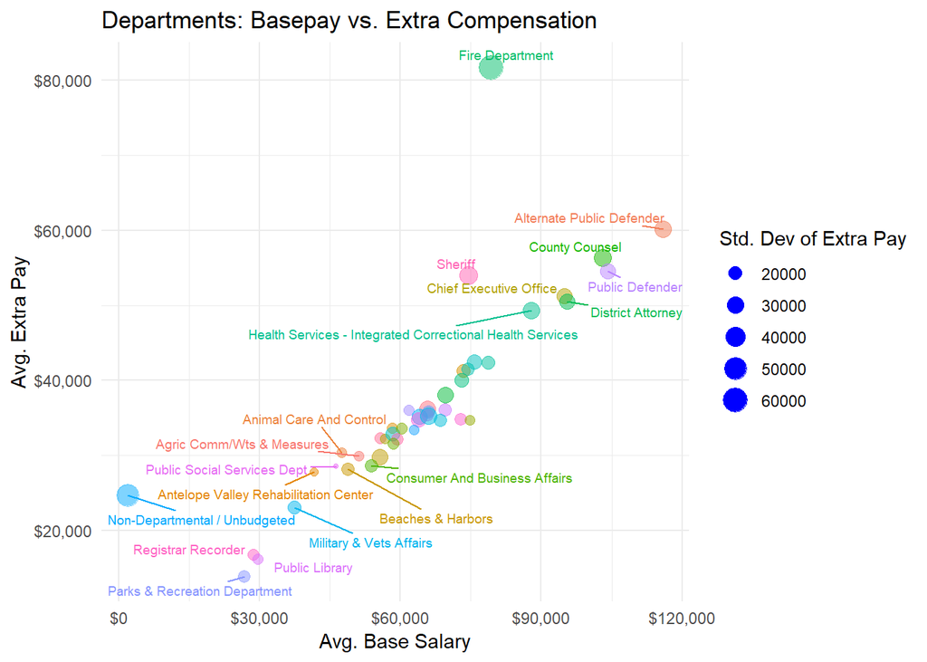

```r
df%>%
    group_by(Department)%>%
    mutate(extra_sal = Total.Compensation - Base.Earnings)%>%
    arrange(desc(extra_sal))%>%
    group_by(Department)%>%
    summarize(n = n(),
              avg_base = mean(Base.Earnings),
              avg_extra = mean(extra_sal),
              sd_extra = sd(extra_sal))%>%
    filter(n > 100)%>%
    mutate(extra_rat = avg_extra/avg_base)%>%
    arrange(desc(extra_rat))%>%
    ungroup()%>%
    ggplot(aes(avg_base, avg_extra, color=Department, size=sd_extra))+
    geom_point(alpha=.5)+
    scale_x_continuous(labels = scales::dollar)+
    scale_y_continuous(labels = scales::dollar)+
    scale_color_discrete()+
    geom_text_repel(aes(label = ifelse(avg_base > 80000 | avg_extra > 50000 | avg_base < 55000 , str_to_title(as.character(Department)), '')), size=2.5, force=8)+
    labs(x='Avg. Base Salary', y='Avg. Extra Pay', title='Departments: Basepay vs. Extra Compensation',
         size='Std. Dev of Extra Pay')+
    theme_minimal()+
    guides(color=FALSE)+
    guides(size=guide_legend(override.aes=list(color= 'blue',alpha=1)))
```

This slightly different version of the previous chart shows the departments and the relationship between base pay and extra pay (Total compensation - base pay). We see a pretty linear relationship here, with a few outliers. Notice that the standard deviation of extra pay is mapped to the size of the point. So for example, non-departmental, Sheriffs, and Fire Department employees have a big variation in extra compensation. In general, this chart reveals that the more your base pay is, the more compensation benefits you tend to receive. And if you’re a fire fighter, you tend to receive a lot more extra compensation than most other departments.

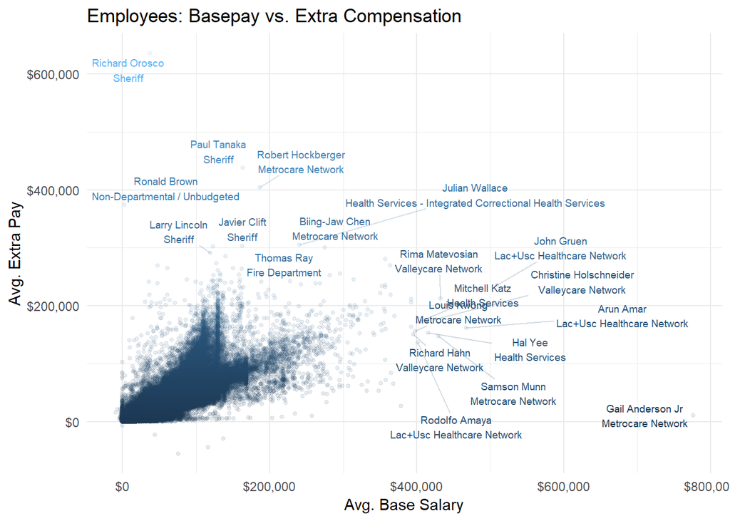

```r
df%>%
    group_by(Employee.Name, Department)%>%
    mutate(extra_sal = Total.Compensation - Base.Earnings)%>%
    arrange(desc(extra_sal))%>%
    group_by(Employee.Name, Department)%>%
    summarize(n = n(),
              avg_base = mean(Base.Earnings),
              avg_extra = mean(extra_sal),
              sd_extra = sd(extra_sal))%>%
    mutate(extra_rat = avg_extra/avg_base)%>%
    arrange(desc(extra_rat))%>%
    ungroup()%>%
    ggplot(aes(avg_base, avg_extra, color=avg_extra))+
    geom_point(alpha=.1, size=1)+
    scale_x_continuous(labels = scales::dollar)+
    scale_y_continuous(labels = scales::dollar)+
    geom_text_repel(aes(label = ifelse(avg_base > 395000 | avg_extra > 290000, str_to_title(as.character(paste(Employee.Name, Department, sep = '\n'))), '')), size=2.5, force=2, segment.alpha = .2)+
    labs(x='Avg. Base Salary', y='Avg. Extra Pay', title='Employees: Basepay vs. Extra Compensation')+
    theme_minimal()+
    guides(color=FALSE)+
    guides(size=guide_legend(override.aes=list(color= 'blue',alpha=1)))
```

I was surprised to learn that county employees could make this much money. I never realized that some police and firefighters were working so much overtime. I’d be curious to hear from some of these people: do they think their work is being fairly compensated? Just judging by the numbers here, I’d be willing to wager most do.

This all goes to show that it’s definitely possible to live a life of affluence as a hard-working firefighter or Sheriff in Southern California. For young people deciding on a career, I would definitely suggest looking at these kinds of city/county jobs, especially since there is a shortage of Sheriffs and wildfires seem to be happening more than ever in California.